# R Users Breakout Session

2022-04-06

## Setup

R users: remember to select a **.dat (fixed-width text)** data format

You’ll receive a compressed **dat.gz** file - no need to decompress!

Save both of those files in the “data” folder of your working directory.

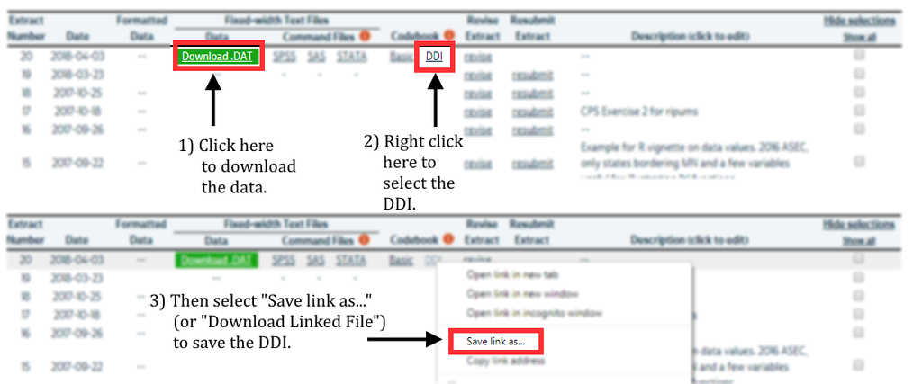

You’ll need the [ipumsr](https://tech.popdata.org/ipumsr/index.html) package to load them. If not installed, you can download from CRAN.

```r
install.packages("ipumsr")
```

Each session, load the `ipumsr` library before you import data.

```r
library(ipumsr)

# Load data into R with `ipumsr`
dat <- read_ipums_micro(
  ddi = "data/pma_00093.xml",
  data = "data/pma_00093.dat.gz"
)
```

[figure not shown]

Other useful packages for IPUMS data:

```r
# General toolkit
library(tidyverse)

# For label manipulation:
library(labelled)

# For survey analysis:
library(survey)
library(srvyr)
```

[figure not shown]

## 1 - Analytic Sample

PMA uses an **open panel design** - women may enter the panel after Phase 1, and they may be lost to follow-up after any phase.

See RESULTFQ

Women who enter the panel at Phase 2 are `NA` for all variables at Phase 1.

```r
dat %>% count(RESULTFQ_1)
```

```
## # A tibble: 3 × 2
##              RESULTFQ_1     n
##               <int+lbl> <int>
## 1  1 [Completed]        16314
## 2  5 [Partly completed]    34
## 3 NA                     4514
```

Women whose households were not found again after Phase 1 are `NA` for all variables at Phase 2.

```r
dat %>% count(RESULTFQ_2)
```

```
## # A tibble: 11 × 2
##                                        RESULTFQ_2     n
##                                         <int+lbl> <int>
##  1  1 [Completed]                                 17015
##  2  2 [Not at home]                                 106
##  3  3 [Postponed]                                    24
##  4  4 [Refused]                                      87
##  5  5 [Partly completed]                             22
##  6  7 [Respondent moved]                             18
##  7 10 [Incapacitated]                                24
##  8 95 [Not interviewed (female questionnaire)]        4
##  9 96 [Not interviewed (household questionnaire)]   197
## 10 99 [NIU (not in universe)]                      1353
## 11 NA                                              2012
```

We will only include women who were available and completed the Female Questionnaire for *both* Phase 1 and Phase 2.

```r
dat <- dat %>% filter(RESULTFQ_1 == 1 & RESULTFQ_2 == 1)

dat %>% count(RESULTFQ_1, RESULTFQ_2)
```

```
## # A tibble: 1 × 3
##      RESULTFQ_1    RESULTFQ_2     n
##       <int+lbl>     <int+lbl> <int>
## 1 1 [Completed] 1 [Completed] 12501
```

Additionally, PMA samples are only valid for the *de facto* population: women who slept in the household the night before the Household interview.

See RESIDENT

```r
dat %>% count(RESIDENT_1)
```

```
## # A tibble: 3 × 2
##                                          RESIDENT_1     n
##                                           <int+lbl> <int>
## 1 11 [Visitor, slept in hh last night]                140
## 2 21 [Usual member, did not sleep in hh last night]   194
## 3 22 [Usual member, slept in hh last night]         12167
```

We’ll also drop cases where the woman was not part of the *de facto* population in either Phase 1 or Phase 2.

```r
dat <- dat %>% filter(RESIDENT_1 %in% c(11, 22) & RESIDENT_2 %in% c(11, 22))
```

How many cases remain?

```r
dat %>% count(COUNTRY)
```

```
## # A tibble: 2 × 2
##            COUNTRY     n
##          <int+lbl> <int>
## 1 1 [Burkina Faso]  5208
## 2 7 [Kenya]         6935
```

## 2 - Recoding Independent variables

PMA surveys contain many **categorical** variables. These are usually represented as **factors** in R.

In an IPUMS data extract, you won’t see factors!

Instead, we generate **labelled** numeric variables (note the label in brackets).

```r
dat %>% ipums_var_label(CVINCOMELOSS_2)
```

```
## [1] "Income loss resulted from COVID-19 restrictions"
```

```r
dat %>% count(CVINCOMELOSS_2)
```

```
## # A tibble: 4 × 2
##               CVINCOMELOSS_2     n
##                    <int+lbl> <int>
## 1  0 [No]                      658
## 2  1 [Yes]                    7566
## 3 97 [Don't know]                2
## 4 99 [NIU (not in universe)]  3917
```

The [ipumsr](https://tech.popdata.org/ipumsr/index.html) package contains tools for working with labelled IPUMS data.

Usually, we handle codes like `99 [NIU (not in universe)]` before transforming other missing data to `NA`.

```r
dat %>% count(CVINCOMELOSS_2, HHINCOMELOSSAMT_2)
```

```
## # A tibble: 7 × 3
##               CVINCOMELOSS_2           HHINCOMELOSSAMT_2     n
##                    <int+lbl>                   <int+lbl> <int>
## 1  0 [No]                     2 [Partial]                  547
## 2  0 [No]                     3 [Complete]                 111
## 3  1 [Yes]                    2 [Partial]                 5449
## 4  1 [Yes]                    3 [Complete]                2117
## 5 97 [Don't know]             2 [Partial]                    2
## 6 99 [NIU (not in universe)]  1 [None]                    3904
## 7 99 [NIU (not in universe)] 98 [No response or missing]    13
```

**Tip:**

Information the code `NIU (not in universe)` can always be found on a variable’s [universe tab](https://pma.ipums.org/pma-action/variables/CVINCOMELOSS#universe_section).

[figure not shown]

For [CVINCOMELOSS_2](https://pma.ipums.org/pma-action/variables/CVINCOMELOSS), `99 [NIU (not in universe)]` may indicate that the household experienced *no income loss in the last year*, or it may indicate that [HHINCOMELOSSAMT_2](https://pma.ipums.org/pma-action/variables/HHINCOMELOSSAMT) is `98 [No response or missing]`.

We should treat the `NIU` women from households without *any* income loss as “No” in [CVINCOMELOSS_2](https://pma.ipums.org/pma-action/variables/CVINCOMELOSS).

```r
dat <- dat %>%
  mutate(
    CVINCOMELOSS_2 = CVINCOMELOSS_2 %>%
      labelled::recode_if(HHINCOMELOSSAMT_2 == 1, 0)
  )

dat %>% count(CVINCOMELOSS_2, HHINCOMELOSSAMT_2)
```

```
## # A tibble: 7 × 3
##               CVINCOMELOSS_2           HHINCOMELOSSAMT_2     n
##                    <int+lbl>                   <int+lbl> <int>
## 1  0 [No]                     1 [None]                    3904
## 2  0 [No]                     2 [Partial]                  547
## 3  0 [No]                     3 [Complete]                 111
## 4  1 [Yes]                    2 [Partial]                 5449
## 5  1 [Yes]                    3 [Complete]                2117
## 6 97 [Don't know]             2 [Partial]                    2
## 7 99 [NIU (not in universe)] 98 [No response or missing]    13
```

Next, we’ll use `NA` to represent the remaining values above `90`:

- `97 [Don't know]` and
- remaining cases marked `99 [NIU (not in universe)]`

```r
dat <- dat %>%
  mutate(
    CVINCOMELOSS_2 = CVINCOMELOSS_2 %>%
      lbl_na_if(~.val > 90)
  )

dat %>% count(CVINCOMELOSS_2, HHINCOMELOSSAMT_2)
```

```
## # A tibble: 7 × 3
##   CVINCOMELOSS_2           HHINCOMELOSSAMT_2     n
##        <int+lbl>                   <int+lbl> <int>
## 1        0 [No]   1 [None]                    3904
## 2        0 [No]   2 [Partial]                  547
## 3        0 [No]   3 [Complete]                 111
## 4        1 [Yes]  2 [Partial]                 5449
## 5        1 [Yes]  3 [Complete]                2117
## 6       NA        2 [Partial]                    2
## 7       NA       98 [No response or missing]    13
```

Once you’re done with labels, we recommend transforming key variables into **factors** with [forcats::as_factor](https://forcats.tidyverse.org/reference/as_factor.html).

The [forcats](https://forcats.tidyverse.org) package is included when you load `library(tidyverse)`.

```r
dat <- dat %>% mutate(CVINCOMELOSS_2 = as_factor(CVINCOMELOSS_2))

dat %>% count(CVINCOMELOSS_2)
```

```
## # A tibble: 3 × 2
##   CVINCOMELOSS_2     n
##   <fct>          <int>
## 1 No              4562
## 2 Yes             7566
## 3 <NA>              15
```

This will make categorical variables easier to use in data visualization and as “dummy” variables in regression analysis.

Likert-style questions can be treated as factors, too.

```r
dat %>% ipums_var_label(COVIDCONCERN_2)
```

```
## [1] "Concerned about getting infected"
```

```r
dat %>% count(COVIDCONCERN_2)
```

```
## # A tibble: 6 × 2
##                                       COVIDCONCERN_2     n
##                                            <int+lbl> <int>
## 1  1 [Not concerned]                                   374
## 2  2 [A little concerned]                              677
## 3  3 [Concerned]                                      2470
## 4  4 [Very concerned]                                 8610
## 5  5 [Currently / previously infected with COVID-19]     9
## 6 98 [No response or missing]                            3
```

This time we’ll treat codes `5` and above as `NA`.

```r
dat <- dat %>%
  mutate(
    COVIDCONCERN_2 = COVIDCONCERN_2 %>%
      lbl_na_if(~.val >= 5) %>%
      as_factor()
  )

dat %>% count(COVIDCONCERN_2)
```

```
## # A tibble: 5 × 2
##   COVIDCONCERN_2         n
##   <fct>              <int>
## 1 Not concerned        374
## 2 A little concerned   677
## 3 Concerned           2470
## 4 Very concerned      8610
## 5 <NA>                  12
```

You can apply the same transformation to several variables with help from [dplyr::across](https://dplyr.tidyverse.org/reference/across.html).

dplyr is another package included when you load `library(tidyverse)`.

```r
dat <- dat %>%
  mutate(
    across(
      c(COUNTRY, URBAN, WEALTHT_2, EDUCATTGEN_2),
      ~.x %>% lbl_na_if(~.val >= 90) %>% as_factor()
    )
  )
```

Often, it’s important to set a **reference group** against which all dummy variables will be compared.

You can manually specify a **refernece group** when you set factor “levels” with a function like [forcats::fct_relevel](https://forcats.tidyverse.org/reference/fct_relevel.html).

```r
dat <- dat %>%
  mutate(
    AGE_2 = case_when(
      AGE_2 < 25 ~ "15-24",
      AGE_2 < 35 ~ "25-34",
      AGE_2 < 50 ~ "35-49"
    ),
    AGE_2 = AGE_2 %>% fct_relevel("15-24", "25-34", "35-49")
  )
```

## 3 - Dependent variables

We’ll use our recoded variables to model the likelihood of contraceptive method **adoption** and **discontinuation** between phases.

```r
dat <- dat %>% filter(CP_1 < 90 & CP_2 < 90)

dat %>% count(CP_1, CP_2)
```

```
## # A tibble: 4 × 3
##        CP_1      CP_2     n
##   <int+lbl> <int+lbl> <int>
## 1   0 [No]    0 [No]   5107
## 2   0 [No]    1 [Yes]  1939
## 3   1 [Yes]   0 [No]   1178
## 4   1 [Yes]   1 [Yes]  3917
```

A woman has **adopted** a method if she was *not* using one at Phase 1, but then reported using one at Phase 2.

She has **discontinued** a method if she *did* use one at Phase 1, but no longer uses one at Phase 2.

```r
dat <- dat %>%
  mutate(
    FPSTATUS = case_when(
      CP_1 == 1 & CP_2 == 1 ~ "User",
      CP_1 == 0 & CP_2 == 0 ~ "Non-user",
      CP_1 == 1 & CP_2 == 0 ~ "Discontinued",
      CP_1 == 0 & CP_2 == 1 ~ "Adopted"
    ),
    FPSTATUS = fct_infreq(FPSTATUS)
  )
```

Un-weighted sample proportions for `FPSTATUS` can be found with [count](https://dplyr.tidyverse.org/reference/count.html) and prop.table:

```r
dat_nowt <- dat %>%
  group_by(COUNTRY) %>%
  count(FPSTATUS) %>%
  mutate(prop = prop.table(n))

dat_nowt
```

```
## # A tibble: 8 × 4
## # Groups:   COUNTRY [2]
##   COUNTRY      FPSTATUS         n   prop
##   <fct>        <fct>        <int>  <dbl>
## 1 Burkina Faso Non-user      2589 0.497
## 2 Burkina Faso User          1241 0.238
## 3 Burkina Faso Adopted        821 0.158
## 4 Burkina Faso Discontinued   556 0.107
## 5 Kenya        Non-user      2518 0.363
## 6 Kenya        User          2676 0.386
## 7 Kenya        Adopted       1118 0.161
## 8 Kenya        Discontinued   622 0.0897
```

We’ll plot this table with [ggplot2](https://ggplot2.tidyverse.org/index.html) (also included with the [tidyverse](https://tidyverse.tidyverse.org/)).

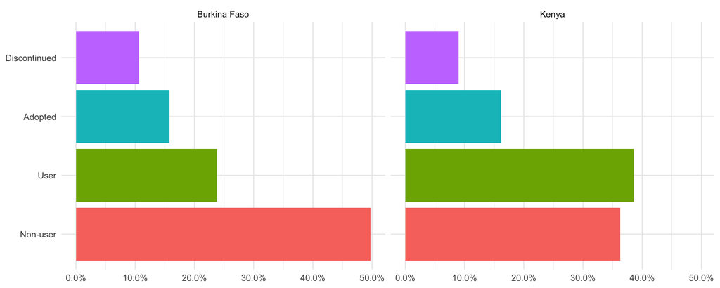

```r
dat_nowt %>%
  ggplot(aes(x = prop, y = FPSTATUS, fill = FPSTATUS)) +
  geom_bar(stat = "identity") +
  facet_wrap(~COUNTRY) + theme_minimal() +
  theme(axis.title = element_blank(), legend.position = "none") +
  scale_x_continuous(labels = scales::label_percent())
```

For *weighted* population estimates, use [as_survey_design](http://gdfe.co/srvyr/reference/as_survey_design.html) and [survey_mean](http://gdfe.co/srvyr/reference/survey_mean.html) from the [srvyr](http://gdfe.co/srvyr/index.html) package.

Use `prop = TRUE` to adjust standard errors near 0% or 100% for proportions.

```r
dat_wtd <- dat %>%
  as_survey_design(weight = PANELWEIGHT, id = EAID_1, strata = STRATA_1) %>%
  group_by(COUNTRY, FPSTATUS) %>%
  summarise(survey_mean(prop = TRUE, prop_method = "logit", vartype = "ci"))

dat_wtd
```

```
## # A tibble: 8 × 5
## # Groups:   COUNTRY [2]
##   COUNTRY      FPSTATUS       coef `_low` `_upp`
##   <fct>        <fct>         <dbl>  <dbl>  <dbl>
## 1 Burkina Faso Non-user     0.563  0.529   0.596
## 2 Burkina Faso User         0.188  0.164   0.214
## 3 Burkina Faso Adopted      0.150  0.133   0.168
## 4 Burkina Faso Discontinued 0.0999 0.0870  0.115
## 5 Kenya        Non-user     0.378  0.361   0.396
## 6 Kenya        User         0.366  0.350   0.382
## 7 Kenya        Adopted      0.165  0.153   0.177
## 8 Kenya        Discontinued 0.0912 0.0830  0.100
```

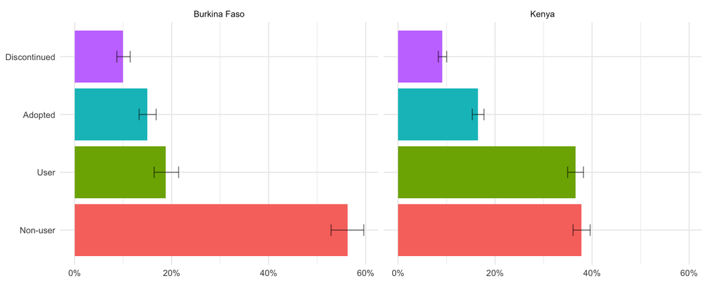

```r
dat_wtd %>%
  ggplot(aes(x = coef, y = FPSTATUS, fill = FPSTATUS)) +
  geom_bar(stat = "identity") +
  geom_errorbar(aes(xmin = `_low`, xmax = `_upp`), width = 0.2, alpha = 0.5) +
  facet_wrap(~COUNTRY) + theme_minimal() +
  theme(axis.title = element_blank(), legend.position = "none") +
  scale_x_continuous(labels = scales::label_percent())
```

## 4 - Analysis

The same [srvyr](http://gdfe.co/srvyr/index.html) toolkit can be used to model our dependent variables with [survey::svyglm](http://r-survey.r-forge.r-project.org/survey/).

Consider women who were *not* using a method at Phase 1:

```r
adopt_glm <- dat %>%
  filter(CP_1 == 0) %>%
  mutate(adopt = FPSTATUS == "Adopted") %>%
  group_by(COUNTRY) %>%
  summarise(
    adopt = cur_data() %>%
      as_survey_design(weight = PANELWEIGHT, id = EAID_1, strata = STRATA_1) %>%
      svyglm(
        adopt ~ CVINCOMELOSS_2 + COVIDCONCERN_2 + URBAN + WEALTHT_2 + EDUCATTGEN_2 + AGE_2,
        family = "quasibinomial", design = .
      ) %>%
      broom::tidy(exp = TRUE) %>%
      mutate(sig = gtools::stars.pval(p.value)) %>%
      list()
  )

adopt_glm
```

```
## # A tibble: 2 × 2
##   COUNTRY      adopt
##   <fct>        <list>
## 1 Burkina Faso <tibble [13 × 6]>
## 2 Kenya        <tibble [13 × 6]>
```

For Phase 1 non-users in Burkina Faso, **very high** levels of concern about becoming infected with COVID-19 are significantly associated with higher chances of adopting a contraceptive method (relative to women who had no such concern).

Lesser levels of concern are not statistically significant, nor is household income loss from COVID-19.

```r
adopt_glm %>%
  filter(COUNTRY == "Burkina Faso") %>%
  unnest(adopt)
```

```
## # A tibble: 13 × 7
##    COUNTRY      term                                estimate std.error statistic       p.value sig
##    <fct>        <chr>                                  <dbl>     <dbl>     <dbl>         <dbl> <chr>
##  1 Burkina Faso (Intercept)                           0.0985     0.366    -6.33  0.00000000262 "***"
##  2 Burkina Faso CVINCOMELOSS_2Yes                     1.28       0.155     1.61  0.109         " "
##  3 Burkina Faso COVIDCONCERN_2A little concerned      1.80       0.373     1.58  0.117         " "
##  4 Burkina Faso COVIDCONCERN_2Concerned               1.37       0.351     0.891 0.375         " "
##  5 Burkina Faso COVIDCONCERN_2Very concerned          1.91       0.318     2.02  0.0446        "*"
##  6 Burkina Faso URBANUrban                            1.36       0.186     1.65  0.101         " "
##  7 Burkina Faso WEALTHT_2Middle tertile               0.962      0.170    -0.230 0.818         " "
##  8 Burkina Faso WEALTHT_2Highest tertile              0.735      0.220    -1.40  0.164         " "
##  9 Burkina Faso EDUCATTGEN_2Primary/Middle school     1.44       0.161     2.24  0.0265        "*"
## 10 Burkina Faso EDUCATTGEN_2Secondary/post-primary    1.51       0.181     2.27  0.0246        "*"
## 11 Burkina Faso EDUCATTGEN_2Tertiary/post-secondary   2.30       0.352     2.37  0.0192        "*"
## 12 Burkina Faso AGE_225-34                            1.72       0.180     3.02  0.00298       "**"
## 13 Burkina Faso AGE_235-49                            1.08       0.195     0.385 0.701         " "
```

In Kenya, neither of these measures are significantly predictive of adoption among non-users.

```r
adopt_glm %>%
  filter(COUNTRY == "Kenya") %>%
  unnest(adopt)
```

```
## # A tibble: 13 × 7
##    COUNTRY term                                estimate std.error statistic  p.value sig
##    <fct>   <chr>                                  <dbl>     <dbl>     <dbl>    <dbl> <chr>
##  1 Kenya   (Intercept)                            0.104     0.371    -6.09  3.76e- 9 "***"
##  2 Kenya   CVINCOMELOSS_2Yes                      1.20      0.111     1.61  1.08e- 1 " "
##  3 Kenya   COVIDCONCERN_2A little concerned       0.645     0.351    -1.25  2.13e- 1 " "
##  4 Kenya   COVIDCONCERN_2Concerned                0.794     0.256    -0.900 3.69e- 1 " "
##  5 Kenya   COVIDCONCERN_2Very concerned           0.907     0.254    -0.385 7.00e- 1 " "
##  6 Kenya   URBANUrban                             1.17      0.147     1.06  2.92e- 1 " "
##  7 Kenya   WEALTHT_2Middle tertile                1.12      0.112     1.01  3.15e- 1 " "
##  8 Kenya   WEALTHT_2Highest tertile               0.817     0.151    -1.34  1.80e- 1 " "
##  9 Kenya   EDUCATTGEN_2Primary/Middle school      2.30      0.273     3.05  2.53e- 3 "**"
## 10 Kenya   EDUCATTGEN_2Secondary/post-primary     2.87      0.302     3.49  5.54e- 4 "***"
## 11 Kenya   EDUCATTGEN_2Tertiary/post-secondary    3.63      0.306     4.21  3.51e- 5 "***"
## 12 Kenya   AGE_225-34                             3.06      0.128     8.71  2.98e-16 "***"
## 13 Kenya   AGE_235-49                             1.61      0.131     3.62  3.53e- 4 "***"
```

What about method **dicontinuation** for women who *were* using a method at Phase 1?

```r
stop_glm <- dat %>%
  filter(CP_1 == 1) %>%
  mutate(stop = FPSTATUS == "Discontinued") %>%
  group_by(COUNTRY) %>%
  summarise(
    stop = cur_data() %>%
      as_survey_design(weight = PANELWEIGHT, id = EAID_1, strata = STRATA_1) %>%
      svyglm(
        stop ~ CVINCOMELOSS_2 + COVIDCONCERN_2 + URBAN + WEALTHT_2 + EDUCATTGEN_2 + AGE_2,
        family = "quasibinomial", design = .
      ) %>%
      broom::tidy(exp = TRUE) %>%
      mutate(sig = gtools::stars.pval(p.value)) %>%
      list()
  )

stop_glm
```

```
## # A tibble: 2 × 2
##   COUNTRY      stop
##   <fct>        <list>
## 1 Burkina Faso <tibble [13 × 6]>
## 2 Kenya        <tibble [13 × 6]>
```

This time, neither of the COVID-19 measures are significantly associated with **discontinuation** for Phase 1 contraceptive users in Burkina Faso.

```r
stop_glm %>%
  filter(COUNTRY == "Burkina Faso") %>%
  unnest(stop)
```

```
## # A tibble: 13 × 7
##    COUNTRY      term                                estimate std.error statistic p.value sig
##    <fct>        <chr>                                  <dbl>     <dbl>     <dbl>   <dbl> <chr>
##  1 Burkina Faso (Intercept)                            0.536     0.407    -1.53   0.127  " "
##  2 Burkina Faso CVINCOMELOSS_2Yes                      0.857     0.185    -0.835  0.405  " "
##  3 Burkina Faso COVIDCONCERN_2A little concerned       1.18      0.442     0.379  0.705  " "
##  4 Burkina Faso COVIDCONCERN_2Concerned                0.922     0.425    -0.192  0.848  " "
##  5 Burkina Faso COVIDCONCERN_2Very concerned           0.935     0.335    -0.200  0.842  " "
##  6 Burkina Faso URBANUrban                             0.951     0.231    -0.215  0.830  " "
##  7 Burkina Faso WEALTHT_2Middle tertile                1.47      0.211     1.82   0.0702 "."
##  8 Burkina Faso WEALTHT_2Highest tertile               0.797     0.238    -0.952  0.343  " "
##  9 Burkina Faso EDUCATTGEN_2Primary/Middle school      1.29      0.212     1.21   0.226  " "
## 10 Burkina Faso EDUCATTGEN_2Secondary/post-primary     1.16      0.250     0.596  0.552  " "
## 11 Burkina Faso EDUCATTGEN_2Tertiary/post-secondary    0.787     0.289    -0.828  0.409  " "
## 12 Burkina Faso AGE_225-34                             1.11      0.215     0.482  0.630  " "
## 13 Burkina Faso AGE_235-49                             0.784     0.244    -0.997  0.320  " "
```

```r
stop_glm %>%
  filter(COUNTRY == "Kenya") %>%
  unnest(stop)
```

```
## # A tibble: 13 × 7
##    COUNTRY term                                estimate std.error statistic  p.value sig
##    <fct>   <chr>                                  <dbl>     <dbl>     <dbl>    <dbl> <chr>
##  1 Kenya   (Intercept)                           0.0978     0.877   -2.65   0.00853  "**"
##  2 Kenya   CVINCOMELOSS_2Yes                     1.01       0.158    0.0433 0.965    " "
##  3 Kenya   COVIDCONCERN_2A little concerned      7.68       0.694    2.94   0.00360  "**"
##  4 Kenya   COVIDCONCERN_2Concerned               4.24       0.723    2.00   0.0467   "*"
##  5 Kenya   COVIDCONCERN_2Very concerned          3.77       0.719    1.85   0.0661   "."
##  6 Kenya   URBANUrban                            1.12       0.135    0.836  0.404    " "
##  7 Kenya   WEALTHT_2Middle tertile               0.843      0.153   -1.11   0.266    " "
##  8 Kenya   WEALTHT_2Highest tertile              0.888      0.180   -0.659  0.511    " "
##  9 Kenya   EDUCATTGEN_2Primary/Middle school     0.787      0.349   -0.687  0.493    " "
## 10 Kenya   EDUCATTGEN_2Secondary/post-primary    0.958      0.367   -0.118  0.907    " "
## 11 Kenya   EDUCATTGEN_2Tertiary/post-secondary   1.10       0.397    0.238  0.812    " "
## 12 Kenya   AGE_225-34                            0.783      0.153   -1.60   0.110    " "
## 13 Kenya   AGE_235-49                            0.589      0.153   -3.45   0.000651 "***"
```

For more R tips for IPUMS data, check out:

- The [IPUMS PMA blog](https://tech.popdata.org/pma-data-hub/)
- The [ipumsr](https://tech.popdata.org/ipumsr/) documentation website
- The [ipums tutorials](https://www.ipums.org/support/tutorials) page

Thank you!